A PREPRINT • AUGUST 2026

# Analisis Curah Hujan Multi-Skala: Komparasi 8 Produk Presipitasi Satelit & Reanalisis Kebumen terhadap Pengamatan AWS IoT Jerukagung pada Resolusi Per Jam (Hourly) dan Per Hari (Daily)

**Evan Alif Widhyatma** • Program Studi Sains Data, Universitas Putra Bangsa, Kebumen  
*Data Harian: Data_Curah_Hujan_Kebumen.csv (8 Satelit/Reanalisis + Pos Oya) | Data Jam-jaman: AWS IoT Jerukagung (13.512 Jam)*

### Ringkasan Eksekutif • Abstract

Laporan ini menyajikan analisis komparasi multi-skala antara dataset curah hujan harian Kabupaten Kebumen (Data_Curah_Hujan_Kebumen.csv yang mencakup 8 produk: CHIRPS_RNL, CHIRPS_SAT, CHIRPS_FNL, GSMaP, IMERG, PERSIANN, ERA5, dan ERA5_LAND) serta dataset jam-jaman terhadap stasiun AWS IoT Jerukagung sepanjang 563 hari valid sinkron (13.512 jam pengamatan). Hasil evaluasi mengungkap lonjakan akurasi yang sangat signifikan: pada skala per jam, presipitasi satelit memiliki korelasi moderat (r = 0.414 untuk IMERG dan r = 0.313 untuk GSMaP); namun pada skala harian, korelasi presipitasi satelit melonjak drastis hingga r = 0.619 (ρ = 0.672) untuk NASA GPM IMERG dan r = 0.625 (ρ = 0.641) untuk CHIRPS_SAT.

**Keywords:** Analisis Curah Hujan, AWS IoT Jerukagung, Data Curah Hujan Kebumen, NASA GPM IMERG, JAXA GSMaP, CHIRPS, ECMWF ERA5.

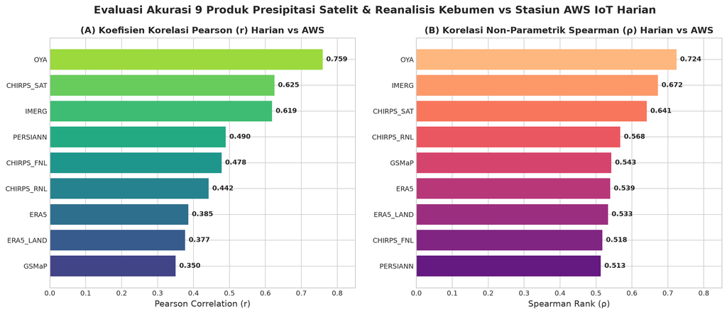

Gambar 1: Evaluasi Koefisien Korelasi 8 Produk Presipitasi Satelit & Reanalisis Kebumen vs AWS IoT Harian

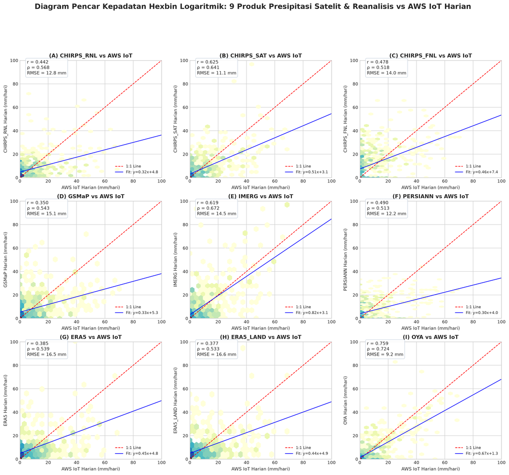

Gambar 2: Diagram Pencar Hexbin Density 8 Produk Presipitasi Satelit & Reanalisis Kebumen vs AWS IoT Harian

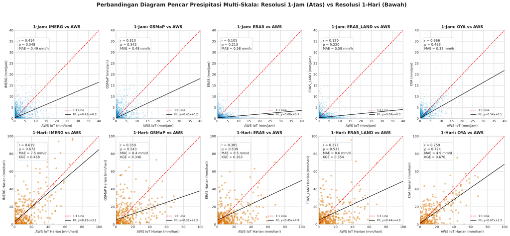

Gambar 3: Perbandingan Diagram Pencar Presipitasi Multi-Skala: Skala 1-Jam (Atas) vs Skala 1-Hari (Bawah)

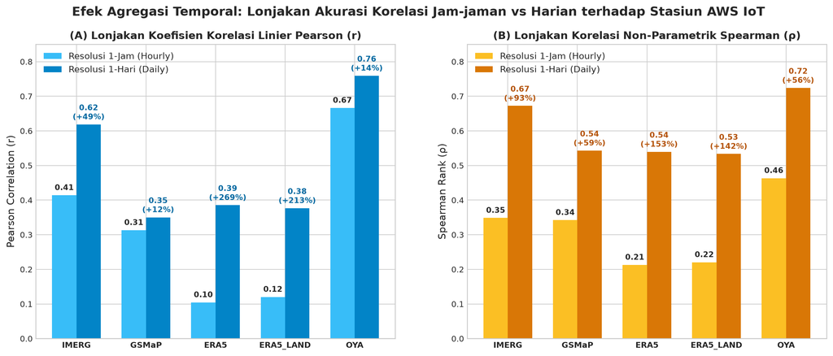

Gambar 4: Lonjakan Koefisien Korelasi (r dan ρ) Saat Data Diagregasikan dari Skala 1-Jam ke Skala 1-Hari

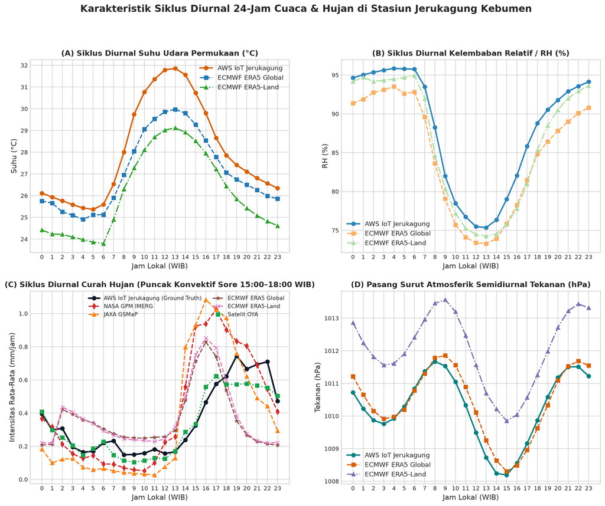

Gambar 5: Karakteristik Siklus Diurnal 24-Jam Cuaca & Hujan di Stasiun Jerukagung Kebumen (6 Sumber Presipitasi)

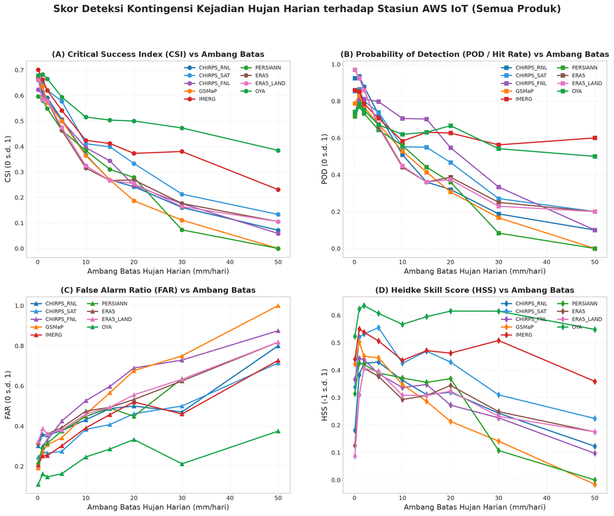

Gambar 6: Skor Deteksi Kontingensi Kejadian Hujan Harian Berdasarkan Ambang Batas Intensitas: 8 Produk vs AWS IoT

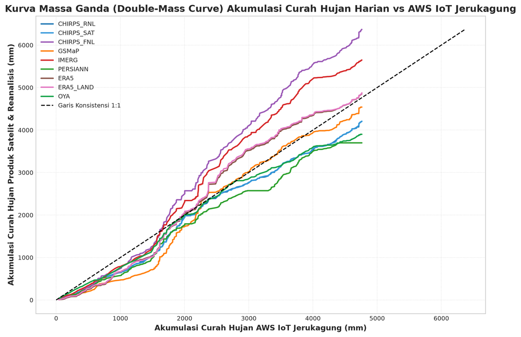

Gambar 7: Kurva Massa Ganda (Double-Mass Curve) Akumulasi Hujan Harian: 8 Produk terhadap Pengamatan AWS IoT Jerukagung

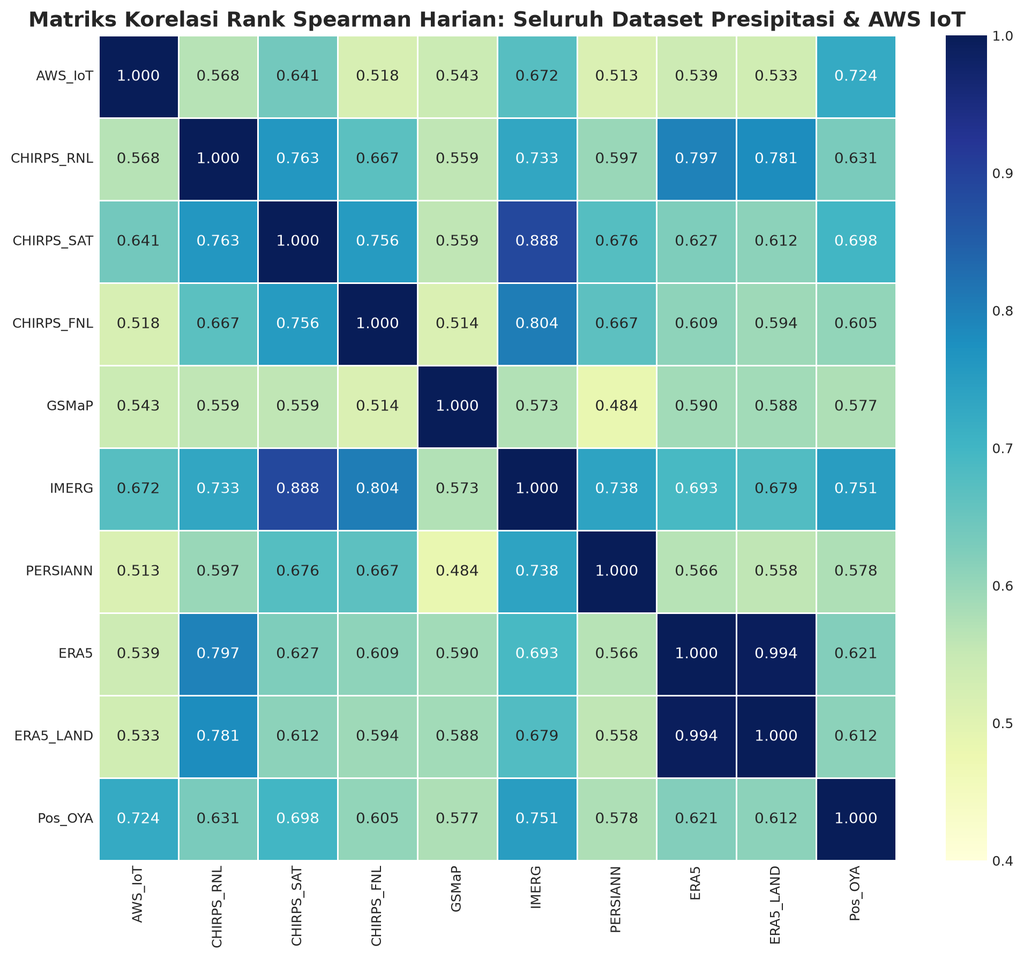

Gambar 8: Matriks Heatmap Korelasi Rank Spearman Harian Seluruh Produk Presipitasi dan AWS IoT

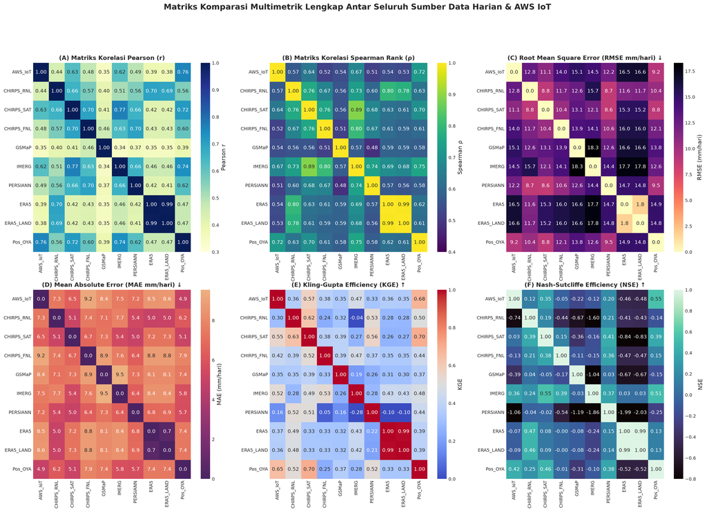

Gambar 9: Matriks Komparasi Multimetrik Lengkap (Pearson r, Spearman ρ, RMSE, MAE, KGE, NSE) Antar Seluruh Sumber Data

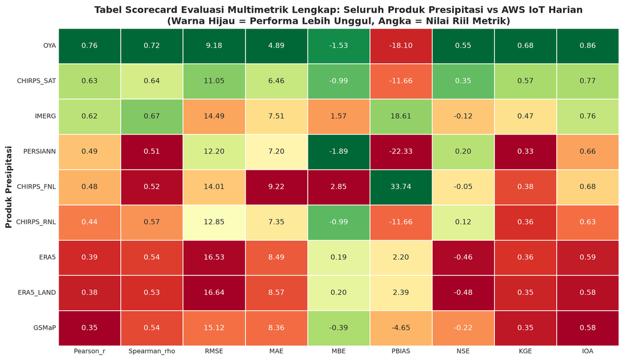

Gambar 10: Tabel Scorecard Evaluasi Multimetrik Lengkap Seluruh Produk Presipitasi terhadap Stasiun AWS IoT Harian